# Übungsfragen Verantwortungsvolles Wirtschaften und Gerechtigkeit

Prof. Dr. Jan S. Voßwinkel

WiSe 2022/23

1. Grenzen Sie Ethik und Moral voneinander ab.
2. Grenzen Sie Wirtschaftsethik vom Begriff der Ethik ab. Diskutieren Sie dabei unterschiedliche Abgrenzungsmöglichkeiten
3. Wie hängt (tendenziell) die Lebenserwartung mit dem BIP pro Kopf zusammen?
4. Wie hat sich (tendenziell) die Einkommensungleichheit innerhalb der Länder weltweit in den letzten dreißig Jahren entwickelt?
5. Systematisieren Sie den Verantwortungsbegriff. Gehen Sie dabei insbesondere auf die folgenden Begriffe ein: Verantwortungssubjekt, -adressat und -instanz.
6. Systematisieren Sie in diesem Zusammenhang die Handlungsfolgen nach den Merkmalen beabsichtigt, vorhergesehen und unvorhergesehen. Unter welchen Umständen sollte ein Handlungssubjekt Ihre Auffassung nach auch für unvorhergesehene Handlungsfolgen verantwortlich gemacht werden können?
7. Tierschutzaktivist $A$ hat es sich zum Ziel gemacht, die Interessen frei lebender Störche zu vertreten. In dieser Funktion zieht er lokale Untermehmen und Behörden zur Verantwortung. Wer ist in dieser Konstellation in den Augen von $A$ Verantwortungssubjekt, -adressat und -instanz? Welche Probleme sehen Sie bei dieser Zuweisung von Positionen?
8. Welche Funktion(en) erfüllt die Zuweisung/Akzeptanz von Verantwortung in Gesellschaften
9. Erläutern Sie anhand eines spieltheoretischen Beispiels den Begriff der Systemverantwortung. Wer ist in diesem Zusammenhang das Verantwortungssubjekt?
10. Was ist ein Gefangenendilemma?
11. Bestimmen Sie für die folgenden drei Spiele die Nash-Gleichgewichte (wenn es welche gibt.)

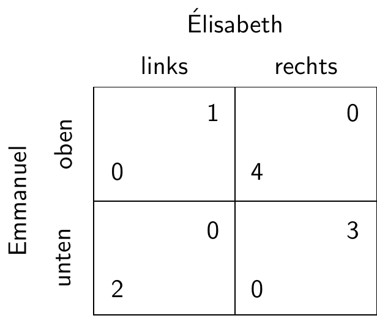

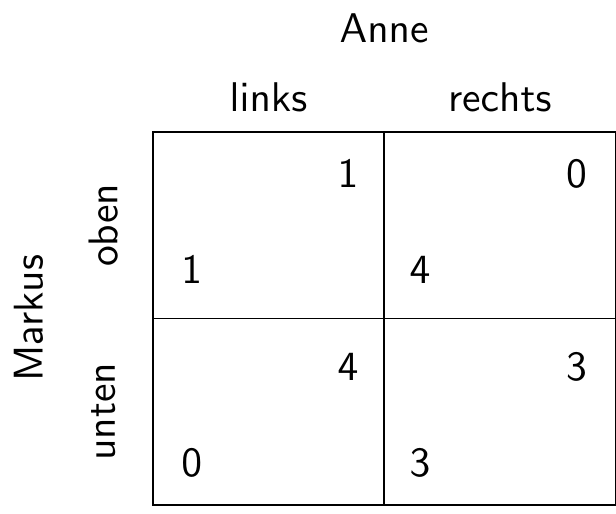

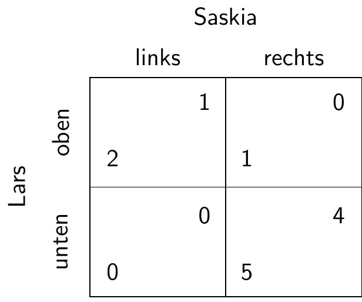

12. Welche Anforderungen stellt Kenneth Arrow an einen Mechanismus zur Aggregation individueller Präferenzen, mit dem eine soziale Wohlfahrtsfunktion ermittelt werden soll?
13. Diskutieren Sie, ob man auf einige dieser Anforderungen in Anbetracht des Unmöglichkeitstheorems verzichten sollte. Welche Konsequenzen wären damit jeweils verbunden?
14. Was ist der sogenannte Schleier des Nichtwissens?
15. Welche Funktion erfüllt er im Rahmen eines Modells eines einstimmigen Konsenses auf Regeln?
16. Welche Eigenschften weisen Regeln auf, die auf einem einstimmigen Konsens hinter dem Schleier des Nichtwissens beruhen?
17. Was meinen horizontale und vertikale Gerechtigkeit?
18. Erörtern Sie, warum eine völlige Gleichverteilung von Einkommen in keiner Gesellschaft zu erwarten ist.
19. Welche Dimensionen der Gerechtigkeit sind nach Enste & Wies (2014) empirisch relevant?
20. Gibt es Ihrer Auffassung nach eine Verantwortung für Bewohner:innen reicherer Staaten zur Unterstützung ärmerer Staaten?